# HW 04 - What should I major in?

Max Asmar

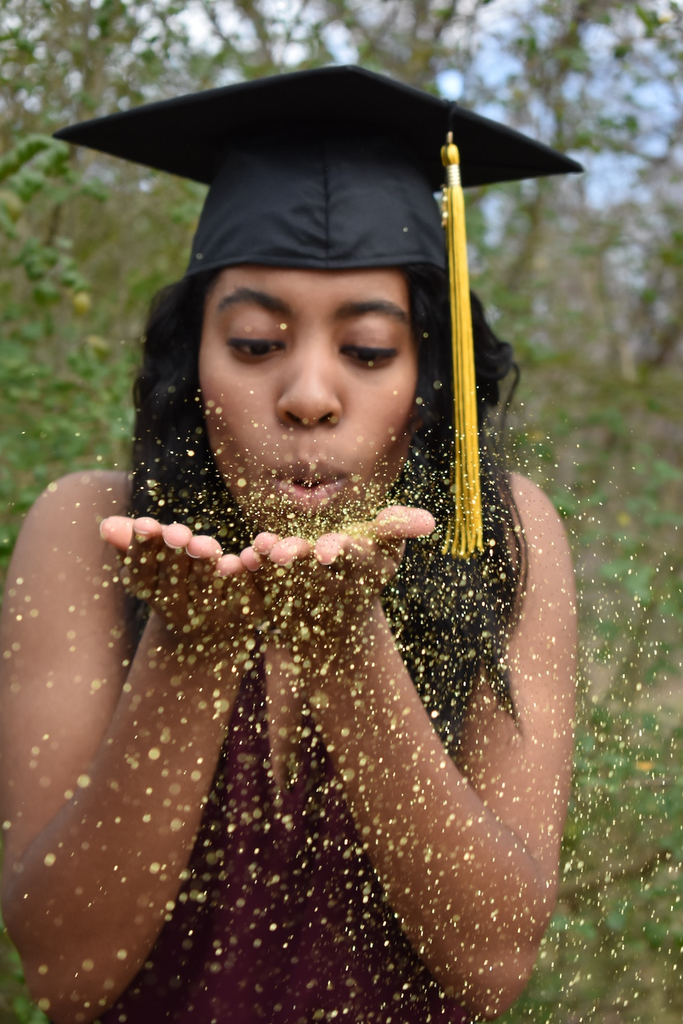

Photo by Marleena Garris on Unsplash

The first step in the process of turning information into knowledge process is to summarize and describe the raw information - the data. In this assignment we explore data on college majors and earnings, specifically the data begin the FiveThirtyEight story [“The Economic Guide To Picking A College Major”](https://fivethirtyeight.com/features/the-economic-guide-to-picking-a-college-major/).

These data originally come from the American Community Survey (ACS) 2010-2012 Public Use Microdata Series. While this is outside the scope of this assignment, if you are curious about how raw data from the ACS were cleaned and prepared, see [the code](https://github.com/fivethirtyeight/data/blob/master/college-majors/college-majors-rscript.R) FiveThirtyEight authors used.

We should also note that there are many considerations that go into picking a major. Earnings potential and employment prospects are two of them, and they are important, but they don’t tell the whole story. Keep this in mind as you analyze the data.

## Learning Objectives

In this assignment, you will practice:

- Using `arrange()`, `select()`, and `filter()` to explore data
- Creating and interpreting histograms with different binwidths
- Calculating summary statistics for distributions
- Using `mutate()` with logical operators to create new variables
- Faceting visualizations to compare groups
- Creating scatterplots with multiple variables

Navigate to your `homework-instructions` repo in JupyterHub, open the `HW04` folder, and open the R Markdown document `hw-04.Rmd`. Knit it to make sure it compiles without errors.

## Warm up

Before we introduce the data, let’s warm up with some simple exercises.

**Complete these steps:**

1. Update the YAML, changing the author name to your name
2. **Knit** the document
3. **Commit** your changes with message: `"Updated author name"`
4. **Push** to GitHub
5. Verify your changes are visible in your GitHub repo (check both .Rmd and .md files)

We’ll use the **tidyverse** package for much of the data wrangling and visualisation, the **scales** package for better formatting of labels on visualisations, and the data lives in the **fivethirtyeight** package. These packages are already installed for you. You can load them by running the following in your Console:

```r
library(tidyverse)
library(scales)
library(fivethirtyeight)
```

## Data

The data can be found in the **fivethirtyeight** package, and it’s called `college_recent_grads`. Since the dataset is distributed with the package, we don’t need to load it separately; it becomes available to us when we load the package. You can find out more about the dataset by inspecting its documentation, which you can access by running `?college_recent_grads` in the Console or using the Help menu in RStudio to search for `college_recent_grads`. You can also find this information [here](https://fivethirtyeight-r.netlify.app/reference/college_recent_grads.html).

You can also take a quick peek at your data frame and view its dimensions with the `glimpse` function.

```r
glimpse(college_recent_grads)
```

The `college_recent_grads` data frame is a trove of information. Let’s think about some questions we might want to answer with these data:

- Which major has the lowest unemployment rate?
- Which major has the highest percentage of women?
- How do the distributions of median income compare across major categories?
- Do women tend to choose majors with lower or higher earnings?

In the next section we aim to answer these questions.

# Exercises

## Which major has the lowest unemployment rate?

In order to answer this question all we need to do is sort the data. We use the `arrange` function to do this, and sort it by the `unemployment_rate` variable. By default `arrange` sorts in ascending order, which is what we want here – we’re interested in the major with the *lowest* unemployment rate.

```r
college_recent_grads %>%
  arrange(unemployment_rate)
```

```
## # A tibble: 173 × 21
##     rank major_code major           major_category total sample_size   men women
##    <int>      <int> <chr>           <chr>          <int>       <int> <int> <int>
##  1    53       4005 Mathematics An… Computers & M…   609           7   500   109
##  2    74       3801 Military Techn… Industrial Ar…   124           4   124     0
##  3    84       3602 Botany          Biology & Lif…  1329           9   626   703
##  4   113       1106 Soil Science    Agriculture &…   685           4   476   209
##  5   121       2301 Educational Ad… Education        804           5   280   524
##  6    15       2409 Engineering Me… Engineering     4321          30  3526   795
##  7    20       3201 Court Reporting Law & Public …  1148          14   877   271
##  8   120       2305 Mathematics Te… Education      14237         123  3872 10365
##  9     1       2419 Petroleum Engi… Engineering     2339          36  2057   282
## 10    65       1100 General Agricu… Agriculture &… 10399         158  6053  4346
## # ℹ 163 more rows
## # ℹ 13 more variables: sharewomen <dbl>, employed <int>,
## #   employed_fulltime <int>, employed_parttime <int>,
## #   employed_fulltime_yearround <int>, unemployed <int>,
## #   unemployment_rate <dbl>, p25th <dbl>, median <dbl>, p75th <dbl>,
## #   college_jobs <int>, non_college_jobs <int>, low_wage_jobs <int>
```

This gives us what we wanted, but not in an ideal form. First, the name of the major barely fits on the page. Second, some of the variables are not that useful (e.g. `major_code`, `major_category`) and some we might want front and center are not easily viewed (e.g. `unemployment_rate`).

We can use the `select` function to choose which variables to display, and in which order:

Note how easily we expanded our code with adding another step to our pipeline, with the pipe operator: `%>%`.

```r
college_recent_grads %>%
  arrange(unemployment_rate) %>%
  select(rank, major, unemployment_rate)
```

```
## # A tibble: 173 × 3
##     rank major                                      unemployment_rate
##    <int> <chr>                                                  <dbl>
##  1    53 Mathematics And Computer Science                     0
##  2    74 Military Technologies                                0
##  3    84 Botany                                               0
##  4   113 Soil Science                                         0
##  5   121 Educational Administration And Supervision           0
##  6    15 Engineering Mechanics Physics And Science            0.00633
##  7    20 Court Reporting                                      0.0117
##  8   120 Mathematics Teacher Education                        0.0162
##  9     1 Petroleum Engineering                                0.0184
## 10    65 General Agriculture                                  0.0196
## # ℹ 163 more rows
```

Ok, this is looking better, but do we really need to display all those decimal places in the unemployment variable? Not really!

We can use the `percent()` function to clean up the display a bit.

```r
college_recent_grads %>%
  arrange(unemployment_rate) %>%
  select(rank, major, unemployment_rate) %>%
  mutate(unemployment_rate = percent(unemployment_rate))
```

```
## # A tibble: 173 × 3
##     rank major                                      unemployment_rate
##    <int> <chr>                                      <chr>
##  1    53 Mathematics And Computer Science           0.00000%
##  2    74 Military Technologies                      0.00000%
##  3    84 Botany                                     0.00000%
##  4   113 Soil Science                               0.00000%
##  5   121 Educational Administration And Supervision 0.00000%
##  6    15 Engineering Mechanics Physics And Science  0.63343%
##  7    20 Court Reporting                            1.16897%
##  8   120 Mathematics Teacher Education              1.62028%
##  9     1 Petroleum Engineering                      1.83805%
## 10    65 General Agriculture                        1.96425%
## # ℹ 163 more rows
```

The major with the lowest unemployment rate are mathematics and computer science, miltiary technologies, botany, soil science, and educational administration and supervision. In the dataset, all of these majors have a 0% unemployment rate.

## Which major has the highest percentage of women?

To answer such a question we need to arrange the data in descending order. For example, if earlier we were interested in the major with the highest unemployment rate, we would use the following:

The `desc` function specifies that we want `unemployment_rate` in descending order.

```r
college_recent_grads %>%
  arrange(desc(unemployment_rate)) %>%
  select(rank, major, unemployment_rate)
```

```
## # A tibble: 173 × 3
##     rank major                                      unemployment_rate
##    <int> <chr>                                                  <dbl>
##  1     6 Nuclear Engineering                                    0.177
##  2    90 Public Administration                                  0.159
##  3    85 Computer Networking And Telecommunications             0.152
##  4   171 Clinical Psychology                                    0.149
##  5    30 Public Policy                                          0.128
##  6   106 Communication Technologies                             0.120
##  7     2 Mining And Mineral Engineering                         0.117
##  8    54 Computer Programming And Data Processing               0.114
##  9    80 Geography                                              0.113
## 10    59 Architecture                                           0.113
## # ℹ 163 more rows
```

1. Using what you’ve learned so far, arrange the data in descending order with respect to proportion of women in a major, and display only the major, the total number of people with major, and proportion of women. Show only the top 3 majors by adding `top_n(3)` at the end of the pipeline.

**Hint:** The variable for proportion of women is `sharewomen`, and total number of people is `total`.

```r
college_recent_grads %>%
  arrange(desc(sharewomen)) %>%
  select(major, total, sharewomen) %>%
  top_n(3)
```

```
## # A tibble: 3 × 3
##   major                                         total sharewomen
##   <chr>                                         <int>      <dbl>
## 1 Early Childhood Education                     37589      0.969
## 2 Communication Disorders Sciences And Services 38279      0.968
## 3 Medical Assisting Services                    11123      0.928
```

The majors with the highest proportion of women are Early Childhood Education, Communication Disorders Sciences and Services, and Medical Assisting Services. The percentage of women in each major is 96.9%, 96.8%, and 92.8% respectively.

## How do the distributions of median income compare across major categories?

A percentile is a measure used in statistics indicating the value below which a given percentage of observations in a group of observations fall. For example, the 20th percentile is the value below which 20% of the observations may be found. (Source: [Wikipedia](https://en.wikipedia.org/wiki/Percentile))

There are three types of incomes reported in this data frame: `p25th`, `median`, and `p75th`. These correspond to the 25th, 50th, and 75th percentiles of the income distribution of sampled individuals for a given major.

2. Why do we often choose the median, rather than the mean, to describe the typical income of a group of people?

We often choose the median rather than the mean to get a better measure of center that is less impacted by outliers in the dataset. For example, a high value would greatly skew the average of a dataset but would not affect the median nearly as much.

The question we want to answer “How do the distributions of median income compare across major categories?”. We need to do a few things to answer this question: First, we need to group the data by `major_category`. Then, we need a way to summarize the distributions of median income within these groups. This decision will depend on the shapes of these distributions. So first, we need to visualize the data.

We use the `ggplot()` function to do this. The first argument is the data frame, and the next argument gives the mapping of the variables of the data to the `aes`thetic elements of the plot.

Let’s start simple and take a look at the distribution of all median incomes, without considering the major categories.

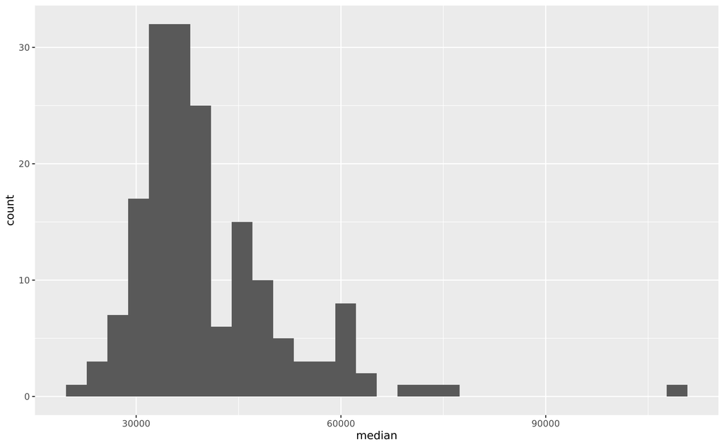

```r
ggplot(data = college_recent_grads, mapping = aes(x = median)) +
  geom_histogram()
```

Along with the plot, we get a message:

```
`stat_bin()` using `bins = 30`. Pick better value with `binwidth`.
```

This is telling us that we might want to reconsider the binwidth we chose for our histogram – or more accurately, the binwidth we didn’t specify. It’s good practice to always think in the context of the data and try out a few binwidths before settling on a binwidth. You might ask yourself: “What would be a meaningful difference in median incomes?” $1 is obviously too little, $10000 might be too high.

3. Try binwidths of $1000 and $5000 and choose one. Explain your reasoning for your choice. Note that the binwidth is an argument for the `geom_histogram` function. So to specify a binwidth of $1000, you would use `geom_histogram(binwidth = 1000)`.

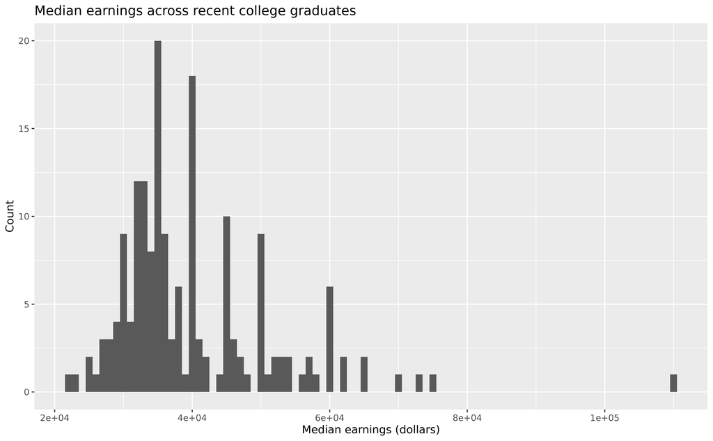

```r
# Try binwidth = 1000
ggplot(data = college_recent_grads, mapping = aes(x = median)) +
  geom_histogram(binwidth = 1000) +
  labs(
    title = "Median earnings across recent college graduates",
    x = "Median earnings (dollars)",
    y = "Count"
  )
```

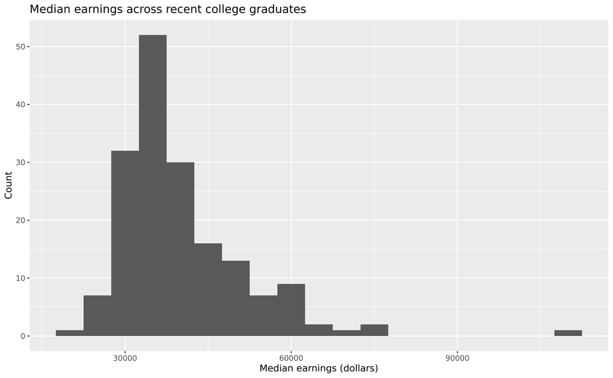

```r
# Try binwidth = 5000
ggplot(data = college_recent_grads, mapping = aes(x = median)) +
  geom_histogram(binwidth = 5000) +
  labs(
    title = "Median earnings across recent college graduates",
    x = "Median earnings (dollars)",
    y = "Count"
  )
```

I think the graph with binwidth as 5000 is more intuitive to read and better shows the general shape of the distribution. I also will use binwidth = 5000 because it is less susceptible to noise in the data than using binwidth = 1000.

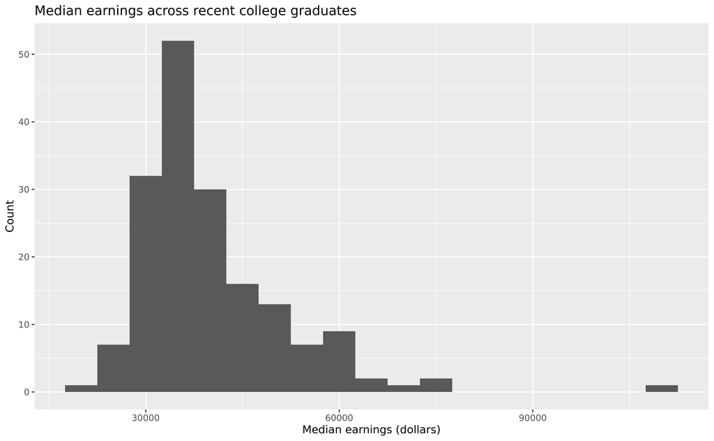

```r
# Try binwidth = 5000
ggplot(data = college_recent_grads, mapping = aes(x = median)) +
  geom_histogram(binwidth = 5000) +
  labs(
    title = "Median earnings across recent college graduates",
    x = "Median earnings (dollars)",
    y = "Count"
  )
```

We can also calculate summary statistics for this distribution using the `summarise` function:

```r
college_recent_grads %>%
  summarise(min = min(median), max = max(median),
            mean = mean(median), med = median(median),
            sd = sd(median),
            q1 = quantile(median, probs = 0.25),
            q3 = quantile(median, probs = 0.75))
```

```
## # A tibble: 1 × 7
##     min    max   mean   med     sd    q1    q3
##   <dbl>  <dbl>  <dbl> <dbl>  <dbl> <dbl> <dbl>
## 1 22000 110000 40151. 36000 11470. 33000 45000
```

4. Based on the shape of the histogram you created in the previous exercise, determine which of these summary statistics is useful for describing the distribution. Write up your description (remember shape, center, spread, any unusual observations) and include the summary statistic output as well.

I think that the minimum and maximum are helpful for describing the distribution, as the minimum median earnings across college majors is 22,000 dollars while the maximum is 110,000 dollars. The graph is skewed right, which is represented in the quartile ranges which are also helpful for describing the distribution. For example, the median of the median earnings across majors is 36,000 dollars which is much closer to the 1st quartile of 33,000 dollars compared to the 3rd quartile of 45,000 dollars. I think using the quartiles is a better measure of the distribution than using the (max-min) range because it is less susceptible to outliers in the dataset. One unusual observation is that the range of the dataset is very large. More specifically, the range is 88,000 dollars.

5. Plot the distribution of `median` income using a histogram, faceted by `major_category`. Use the `binwidth` you chose in the earlier exercise.

**Hint:** Add `facet_wrap(~major_category)` to your ggplot code.

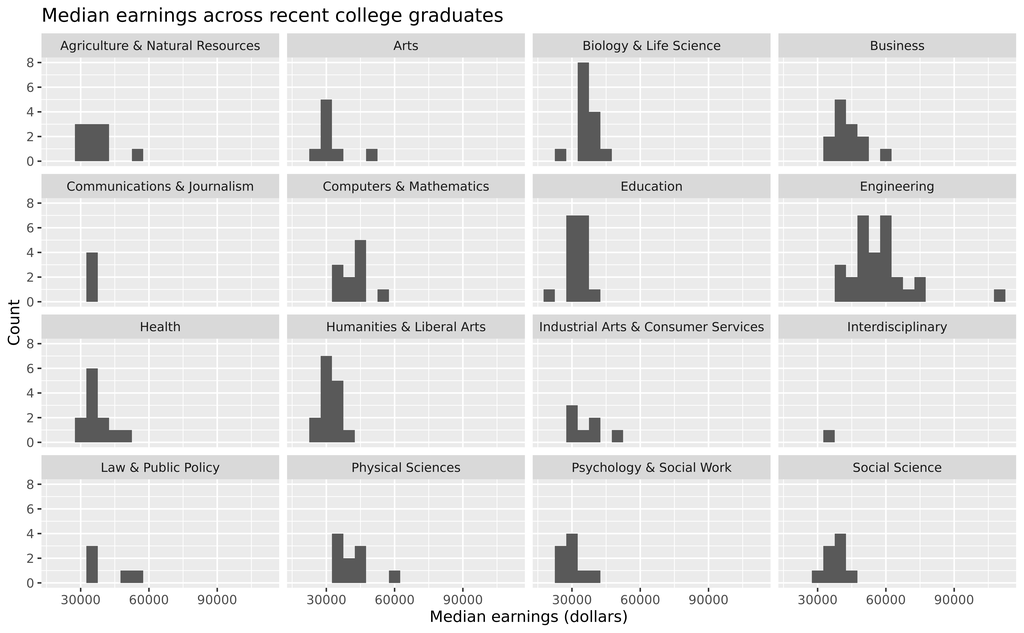

```r
ggplot(data = college_recent_grads, mapping = aes(x = median)) +
  geom_histogram(binwidth = 5000) +
  labs(
    title = "Median earnings across recent college graduates",
    x = "Median earnings (dollars)",
    y = "Count"
  ) +
  facet_wrap(~major_category)
```

Now that we’ve seen the shapes of the distributions of median incomes for each major category, we should have a better idea for which summary statistic to use to quantify the typical median income.

6. Which major category has the highest typical (you’ll need to decide what this means) median income? Use the partial code below, filling it in with the appropriate statistic and function. Also note that we are looking for the highest statistic, so make sure to arrange in the correct direction.

Fill-in the blanks in the code below and change eval = TRUE to test your output.

```r
college_recent_grads %>%
  group_by(major_category) %>%
  summarise(mean = mean(median)) %>%
  arrange(desc(mean))
```

```
## # A tibble: 16 × 2
##    major_category                        mean
##    <chr>                                <dbl>
##  1 Engineering                         57383.
##  2 Business                            43538.
##  3 Computers & Mathematics             42745.
##  4 Law & Public Policy                 42200
##  5 Physical Sciences                   41890
##  6 Social Science                      37344.
##  7 Agriculture & Natural Resources     36900
##  8 Health                              36825
##  9 Biology & Life Science              36421.
## 10 Industrial Arts & Consumer Services 36343.
## 11 Interdisciplinary                   35000
## 12 Communications & Journalism         34500
## 13 Arts                                33062.
## 14 Education                           32350
## 15 Humanities & Liberal Arts           31913.
## 16 Psychology & Social Work            30100
```

Using the greatest mean as a measure of highest typical median income across major categories, I observe that engineering has the highest typical median income with a mean of 57,383 dollars.

7. Which major category is the least popular in this sample? To answer this question we use a new function called `count`, which first groups the data and then counts the number of observations in each category (see below). Add to the pipeline appropriately to arrange the results so that the major with the lowest observations is on top.

```r
college_recent_grads %>%
  count(major_category) %>%
  arrange(n)
```

```
## # A tibble: 16 × 2
##    major_category                          n
##    <chr>                               <int>
##  1 Interdisciplinary                       1
##  2 Communications & Journalism             4
##  3 Law & Public Policy                     5
##  4 Industrial Arts & Consumer Services     7
##  5 Arts                                    8
##  6 Psychology & Social Work                9
##  7 Social Science                          9
##  8 Agriculture & Natural Resources        10
##  9 Physical Sciences                      10
## 10 Computers & Mathematics                11
## 11 Health                                 12
## 12 Business                               13
## 13 Biology & Life Science                 14
## 14 Humanities & Liberal Arts              15
## 15 Education                              16
## 16 Engineering                            29
```

The interdisciplinary major category is the least popular in this sample with only 1 observation.

🧶 Knit → ✅ Commit with message `"Completed Exercise 1-7"` → ⬆️ Push

## All STEM fields aren’t the same

One of the sections of the [FiveThirtyEight story](https://fivethirtyeight.com/features/the-economic-guide-to-picking-a-college-major/) is “All STEM fields aren’t the same”. Let’s see if this is true.

First, let’s create a new vector called `stem_categories` that lists the major categories that are considered STEM fields.

```r
stem_categories <- c("Biology & Life Science",
                     "Computers & Mathematics",
                     "Engineering",
                     "Physical Sciences")
```

Then, we can use this to create a new variable in our data frame indicating whether a major is STEM or not.

```r
college_recent_grads <- college_recent_grads %>%
  mutate(major_type = ifelse(major_category %in% stem_categories, "stem", "not stem"))
```

Let’s unpack this: with `mutate` we create a new variable called `major_type`, which is defined as `"stem"` if the `major_category` is in the vector called `stem_categories` we created earlier, and as `"not stem"` otherwise.

`%in%` is a **logical operator**. Other logical operators that are commonly used are

| Operator | Operation |
| --- | --- |
| `x < y` | less than |
| `x > y` | greater than |
| `x <= y` | less than or equal to |
| `x >= y` | greater than or equal to |
| `x != y` | not equal to |
| `x == y` | equal to |
| `x %in% y` | contains |
| `x \| y` | or |
| `x & y` | and |
| `!x` | not |

We can use the logical operators to also `filter` our data for STEM majors whose median earnings is less than median for all majors’ median earnings, which we found to be $36,000 earlier.

```r
college_recent_grads %>%
  filter(
    major_type == "stem",
    median < 36000
  )
```

8. Which STEM majors have median salaries equal to or less than the median for all majors’ median earnings? Your output should only show the major name and median, 25th percentile, and 75th percentile earning for that major as and should be sorted such that the major with the highest median earning is on top.

**Hint:** Use `filter()` with two conditions, then `select()` the relevant variables, then `arrange()` appropriately.

```r
college_recent_grads %>%
  filter(
    major_type == "stem",
    median <= 36000
  ) %>%
  select(major, median, p25th, p75th) %>%
  arrange(desc(median))
```

```
## # A tibble: 11 × 4
##    major                                 median p25th p75th
##    <chr>                                  <dbl> <dbl> <dbl>
##  1 Geosciences                            36000 21000 41000
##  2 Environmental Science                  35600 25000 40200
##  3 Multi-Disciplinary Or General Science  35000 24000 50000
##  4 Physiology                             35000 20000 50000
##  5 Communication Technologies             35000 25000 45000
##  6 Neuroscience                           35000 30000 44000
##  7 Atmospheric Sciences And Meteorology   35000 28000 50000
##  8 Miscellaneous Biology                  33500 23000 48000
##  9 Biology                                33400 24000 45000
## 10 Ecology                                33000 23000 42000
## 11 Zoology                                26000 20000 39000
```

## What types of majors do women tend to major in?

9. Create a scatterplot of median income vs. proportion of women in that major, coloured by whether the major is in a STEM field or not. Describe the association between these three variables.

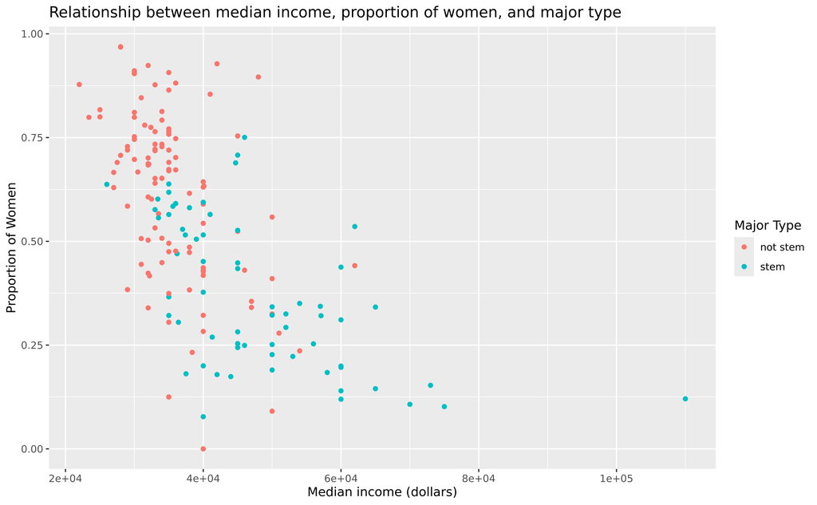

```r
ggplot(data = college_recent_grads, aes(x = median, y = sharewomen, color = major_type)) +
  geom_point() +
  labs(
    x = "Median income (dollars)",
    y = "Proportion of Women",
    color = "Major Type",
    title = "Relationship between median income, proportion of women, and major type"
  )
```

There is a negative association between proportion of women in a college major and median income. In other words, majors with more women are associated with lower median incomes. Many of these majors with more women are in non-stem fields, which you can see by the concentration of red points in the top left of the graph and concentration of blue points towards the bottom middle of the graph. Because women might often feel more valued and included in these majors rather than higher income majors, it could perpetuate income inequality between men and women.

## Further exploration

10. Ask a question of interest to you, and answer it using summary statistic(s) and/or visualization(s).

**Some ideas to explore:** - Which major has the best employment prospects (highest employed, lowest unemployed)? - How does the proportion of women vary across major categories? - What is the relationship between sample size and median income? - Do majors with higher proportions of full-time workers have higher median incomes?

**Your research question:** Which major category has the best employment prospects?

**Your analysis (code and visualization/summary statistics):**

```r
college_recent_grads %>%
  group_by(major_category) %>%
  summarise(
    employment_rate = median(employed/(unemployed+employed)),
    unemployment_rate = median(unemployed/(unemployed+employed)),
    full_time_to_part_time_proportion = median(employed_fulltime/employed_parttime)
  )
```

```
## # A tibble: 16 × 4
##    major_category       employment_rate unemployment_rate full_time_to_part_ti…¹
##    <chr>                          <dbl>             <dbl>                  <dbl>
##  1 Agriculture & Natur…           0.945            0.0553                   3.11
##  2 Arts                           0.911            0.0895                   1.78
##  3 Biology & Life Scie…           0.932            0.0680                   2.16
##  4 Business                       0.930            0.0697                   5.00
##  5 Communications & Jo…           0.928            0.0722                   3.09
##  6 Computers & Mathema…           0.909            0.0908                   4.89
##  7 Education                      0.951            0.0488                   3.32
##  8 Engineering                    0.940            0.0598                   4.20
##  9 Health                         0.936            0.0643                   1.73
## 10 Humanities & Libera…           0.918            0.0817                   1.97
## 11 Industrial Arts & C…          NA               NA                        4.44
## 12 Interdisciplinary              0.929            0.0709                   2.53
## 13 Law & Public Policy            0.918            0.0825                   3.41
## 14 Physical Sciences              0.949            0.0511                   2.40
## 15 Psychology & Social…           0.935            0.0651                   2.59
## 16 Social Science                 0.903            0.0972                   2.48
## # ℹ abbreviated name: ¹full_time_to_part_time_proportion
```

**Your findings (3-4 sentences):**

Looking at my summary statistics, I can see that the major categories with the greatest employment rates are Education, Physical Sciences, and Agriculture. The major categories with the highest unemployment rates are Computers & Mathematics, Social Science, and Arts. I also notice that the business major category is the most likely to be employed full time compared to part time, with a ratio of 5:1. In comparison, the major category that is the least likely to be employed full time compared to part time is Health. One thing I noticed however, was that the employment rate and unemployment rate for the Industrial Arts major category has a value of “NA”. I think this means that the denominator might be 0 meaning there are not enough observations of unemployed and/or employed graduates.

🧶 Knit → ✅ Commit with message `"Completed Exercise 8-10"` → ⬆️ Push

## Common Errors and Troubleshooting

**Data manipulation errors:**

- **Error: “object ‘major_type’ not found”** → Make sure you ran the `mutate()` code that creates the `major_type` variable
- **`arrange()` not sorting correctly** → Use `desc()` for descending order: `arrange(desc(variable))`
- **`filter()` with multiple conditions not working** → Make sure conditions are separated by commas or use `&`

**Visualization errors:**

- **Histogram binwidth warning** → Specify a binwidth: `geom_histogram(binwidth = 1000)`
- **Facets not appearing** → Check spelling of `facet_wrap(~variable)`
- **Scatterplot colors not showing** → Make sure `color = variable` is inside `aes()`

**Function errors:**

- **Error: “could not find function”** → Load required packages: `library(tidyverse)`, `library(scales)`, `library(fivethirtyeight)`
- **`top_n()` not working** → Make sure it’s at the end of your pipeline
- **`percent()` function error** → Load the scales package: `library(scales)`

**General issues:**

- **Code chunk not running** → Remove `eval = FALSE` from chunk options
- **Summary statistics returning NA** → Check for missing values; use `na.rm = TRUE` if needed
- **Pipeline errors** → Check that each line (except the last) ends with `%>%`

**To submit:**

1. Review your write-up to make sure you’ve answered all questions
2. Check that all R chunks are properly labeled
3. Click the **Knit** dropdown menu (next to the Knit button)
4. Select **Knit to tufte_handout** to generate a PDF
5. Download the PDF file from your Files pane
6. Upload the PDF to Canvas

**✓ Final check:** Visit your GitHub repo to confirm all your commits are there!